# Intro to colR

Dr Annie Quinn (annievisserquinn@gmail.com)

2020-11-12

[figure not shown]

## 1. Getting started

- Use the `devtools` package to install `colR` from GitHub: `devtools::install_github("avisserquinn/colR")`
- Load `colR` in R using `library(colR)`

If using the package manager `pacman`:

- Install and update `colR` using `pacman::p_install_gh("avisserquinn/colR")`
- Load `colR` in R using `pacman::p_load(colR)`

*Note: colR is under development. Check for updates on each use.*

## 2. Functions

```r
library(colR)
```

For ease of use, each `colR` function has the prefix *colR*. Print all functions using `ls("package:colR")`:

```
## [1] "colRcvd"  "colRplot" "colRtidy"
```

### 2.1 Example 1 - One colour

Let’s explore the functions `colRplot()` and `colRcvd()` using a single colour, `#38A9AC` (the main colour in the colR hex sticker).

```r
myCol <- "#38A9AC"
```

The function `colRplot()` uses ggplot to visualise the colour. The colour is overlaid with the corresponding hex code.

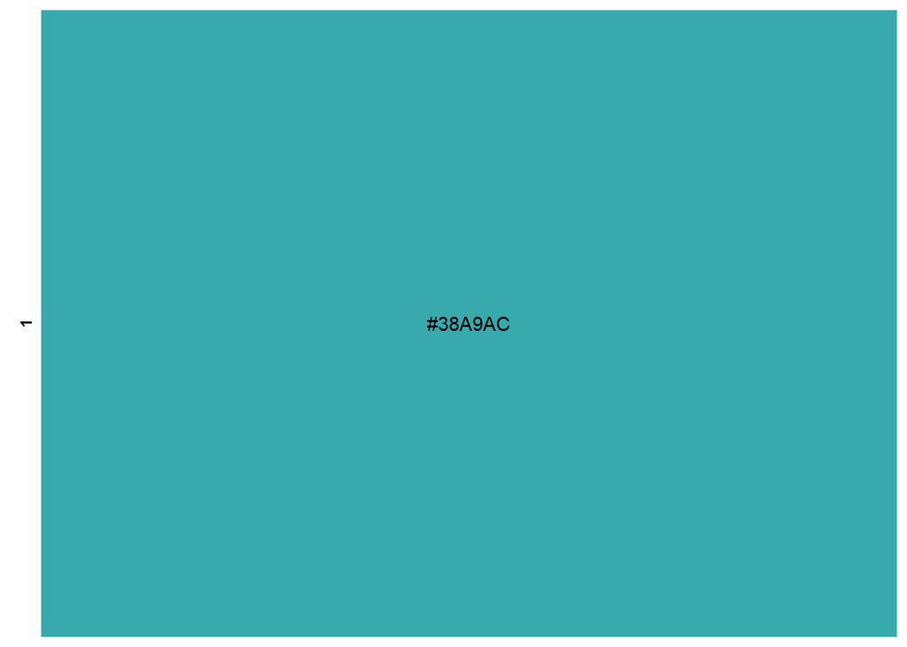

```r
myCol %>% colRplot
```

The function `colRcvd()` transforms colour(s) to simulate three types of colour vision deficiency (cvd):

- Deutanomaly
- Protanomaly
- Tritanomaly

For ease of use, only the first three characters are required. It is *not* case sensitive.

The following examples all have the same output, #7F89AD, a hex colour in vector form.

```r
myCol %>% colRcvd(cvd = "deu")
myCol %>% colRcvd(cvd = "deutanomaly")
myCol %>% colRcvd(cvd = "Deutanomaly")
myCol %>% colRcvd(cvd = "deuteranopia")
```

Omit the cvd argument to simulate all three types of colour vision deficiency.

```r
myCol %>% colRcvd
```

```
##  original       deu       pro       tri
## "#38A9AC" "#7F89AD" "#979CAD" "#1BB2A9"
```

Combine `colRcvd()` with `colRplot()` to visualise.

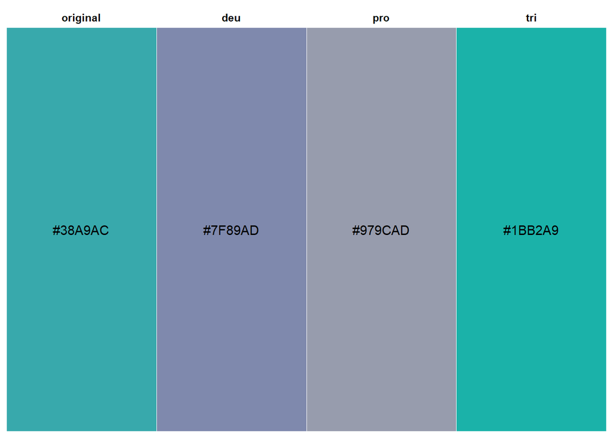

```r
myCol %>% colRcvd %>% colRplot
```

Now let’s look at a vector of multiple colours.

```r
myCol <- c("#2ECC71", "#F1C40F", "#E74C3C")
```

But what colours are they? We can easily visualise them using `colRplot()`.

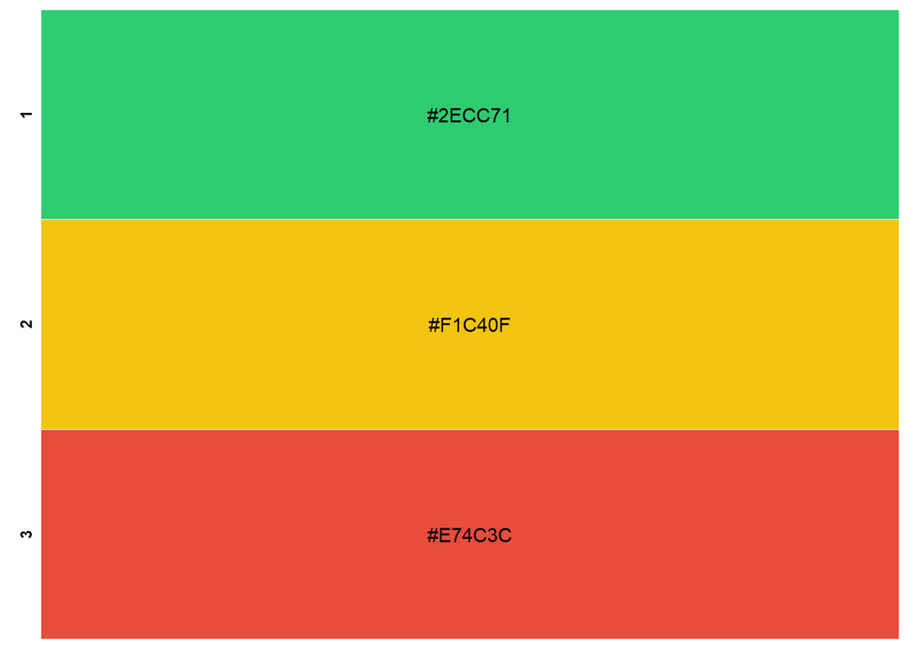

```r
myCol %>% colRplot
```

As before, the colours are labelled with their hex code. On the left-hand side you can see the colour number, this is the colour index, or position, in the vector.

How does cvd change these colours?

```r
myCol %>% colRcvd
```

```
##      original  deu       pro       tri
## [1,] "#2ECC71" "#A79B76" "#C7B16D" "#16CBB0"
## [2,] "#F1C40F" "#FEC814" "#F0B705" "#FFA68D"
## [3,] "#E74C3C" "#89773B" "#675C3B" "#FF3D48"
```

This time the output is a matrix, not a vector. Use `colRtidy()` to tidy the matrix for input to `colRplot()`.

```r
myCol%>% colRcvd %>% colRtidy
```

```
## # A tibble: 12 x 3
##        i type     hex
##    <int> <chr>    <chr>
##  1     1 original #2ECC71
##  2     2 original #F1C40F
##  3     3 original #E74C3C
##  4     1 deu      #A79B76
##  5     2 deu      #FEC814
##  6     3 deu      #89773B
##  7     1 pro      #C7B16D
##  8     2 pro      #F0B705
##  9     3 pro      #675C3B
## 10     1 tri      #16CBB0
## 11     2 tri      #FFA68D
## 12     3 tri      #FF3D48
```

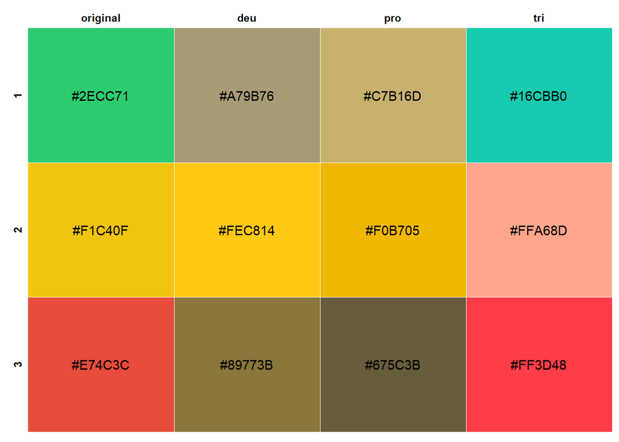

```r
myCol %>% colRcvd %>% colRtidy %>% colRplot
```

## 3. Example applications

### 3.1 Visualising colour palettes

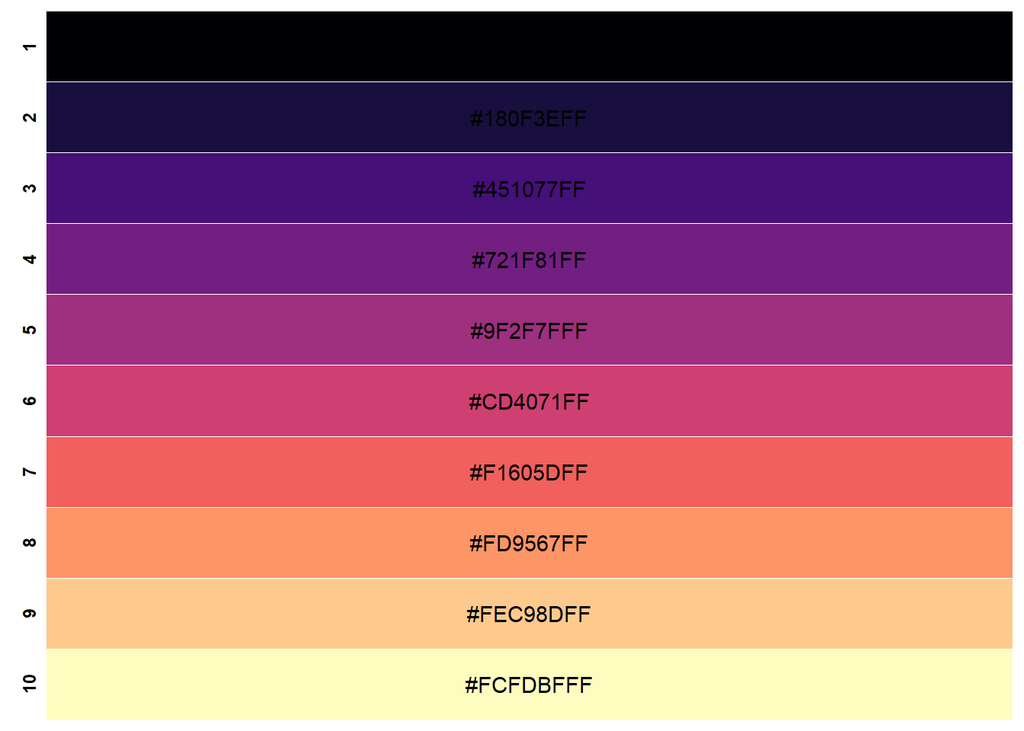

```r
viridis::viridis(option = "A", n = 10) %>% colRplot
```

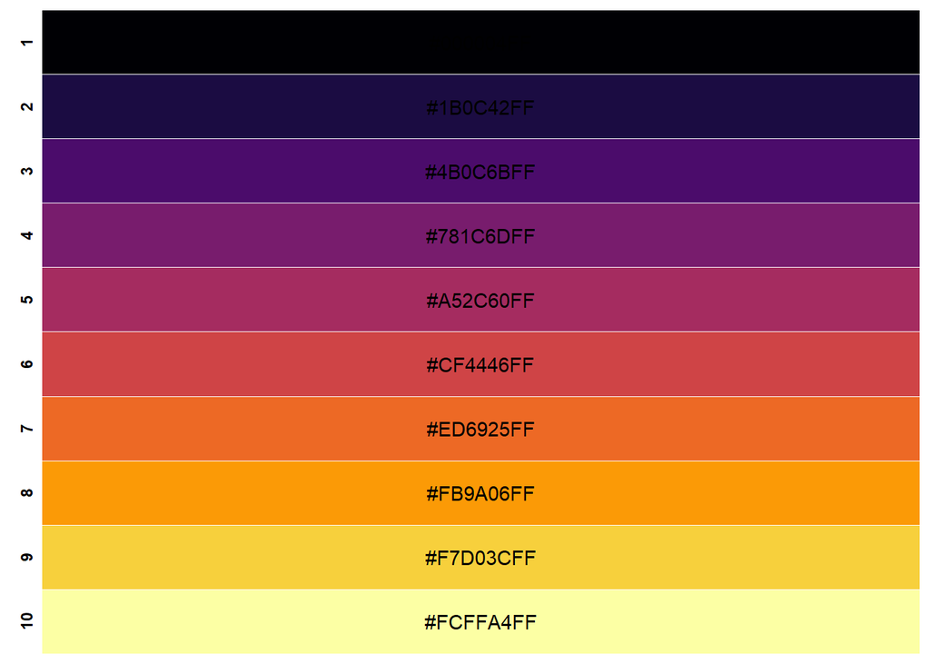

```r
viridis::viridis(option = "B", n = 10) %>% colRplot
```

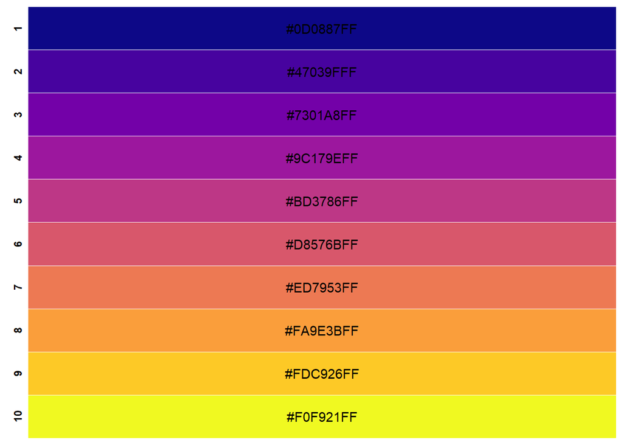

```r
viridis::viridis(option = "C", n = 10) %>% colRplot
```

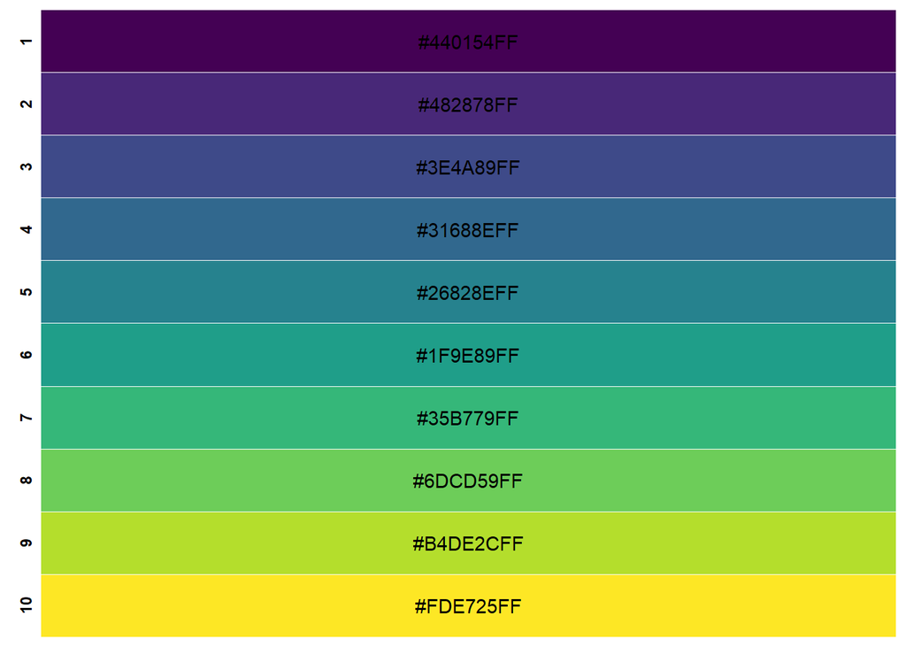

```r
viridis::viridis(option = "D", n = 10) %>% colRplot
```

### 3.2 Finding a distinct colour colour palette

Check out the first two colour palettes from viridis.

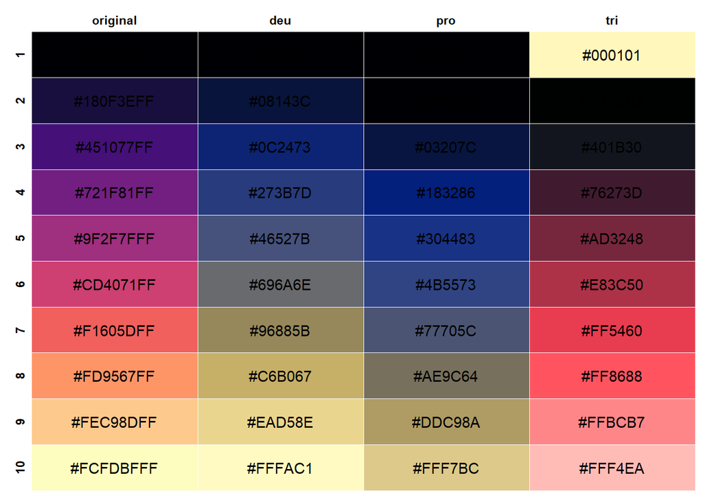

```r
viridis::viridis(option = "A", n = 10) %>%
  colRcvd %>%
  colRtidy %>%
  colRplot
```

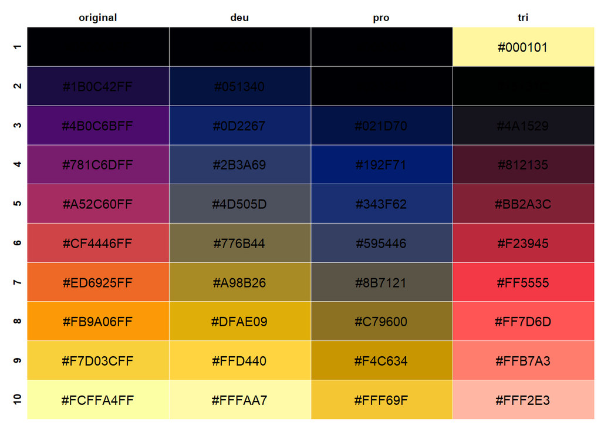

```r
viridis::viridis(option = "B", n = 10) %>%
  colRcvd %>%
  colRtidy %>%
  colRplot
```

The first colours are not very distinct! They’re not well-suited for a qualitative palette.

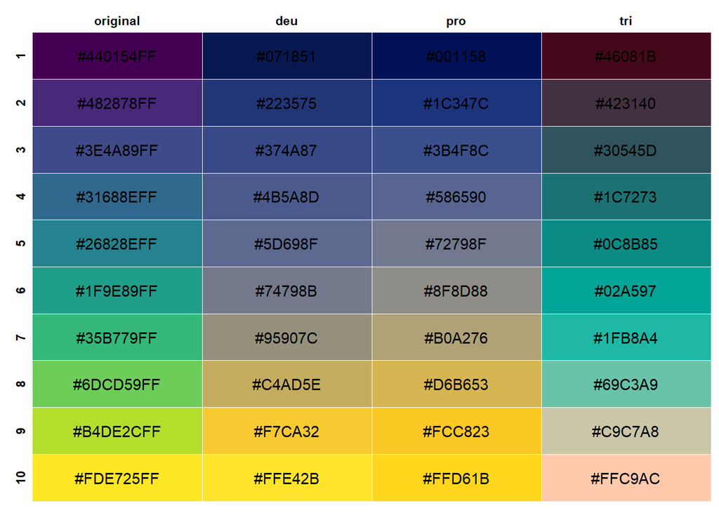

```r
viridis::viridis(option = "D", n = 10) %>%
  colRcvd %>%
  colRtidy %>%
  colRplot
```

Option D is a much more distinct option.

### 3.3 Finding a colour blind friendly distinct colour palette

Let’s check out how accessible Paul Tol’s colour palettes are; we can do this via the khroma package, https://cran.r-project.org/web/packages/khroma/vignettes/tol.html. The bright, contrast, vibrant and muted colour schemes should be colour blind friendly.

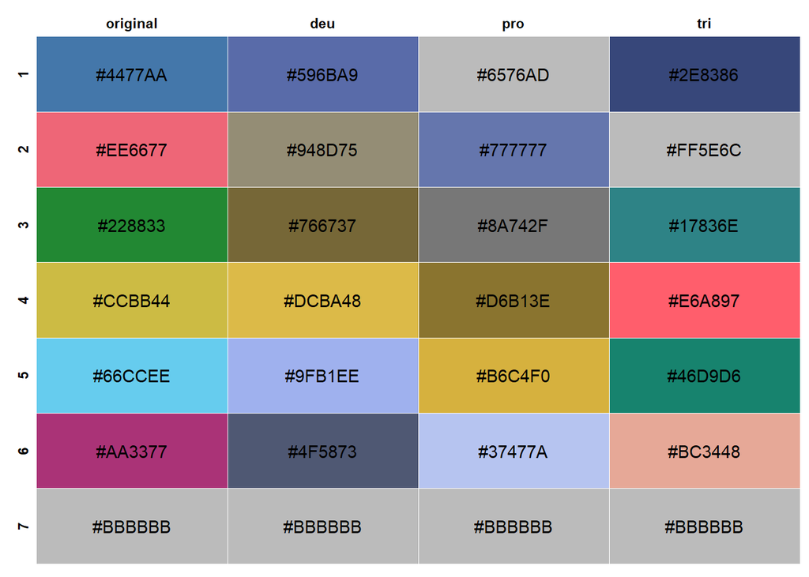

```r
khroma::colour("bright")(7) %>% as.vector %>% colRcvd %>% colRtidy %>% colRplot
```

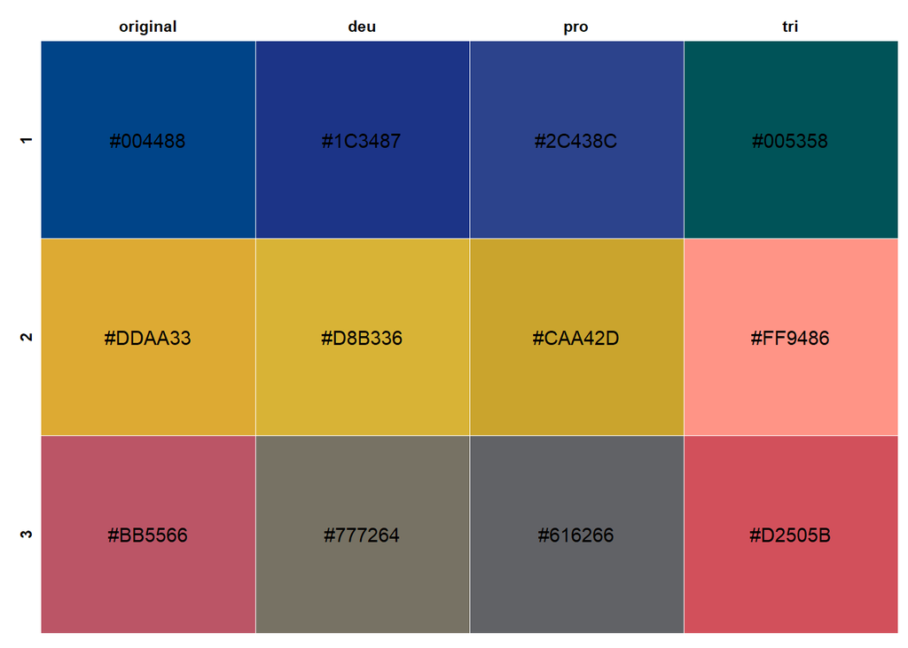

```r
khroma::colour("contrast")(3) %>% as.vector %>% colRcvd %>% colRtidy %>% colRplot
```

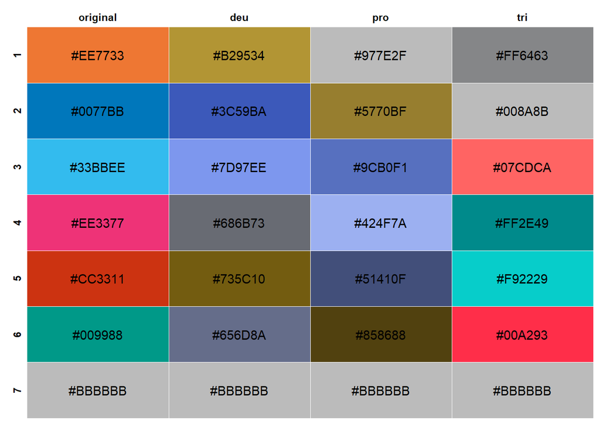

```r
khroma::colour("vibrant")(7) %>% as.vector %>% colRcvd %>% colRtidy %>% colRplot
```

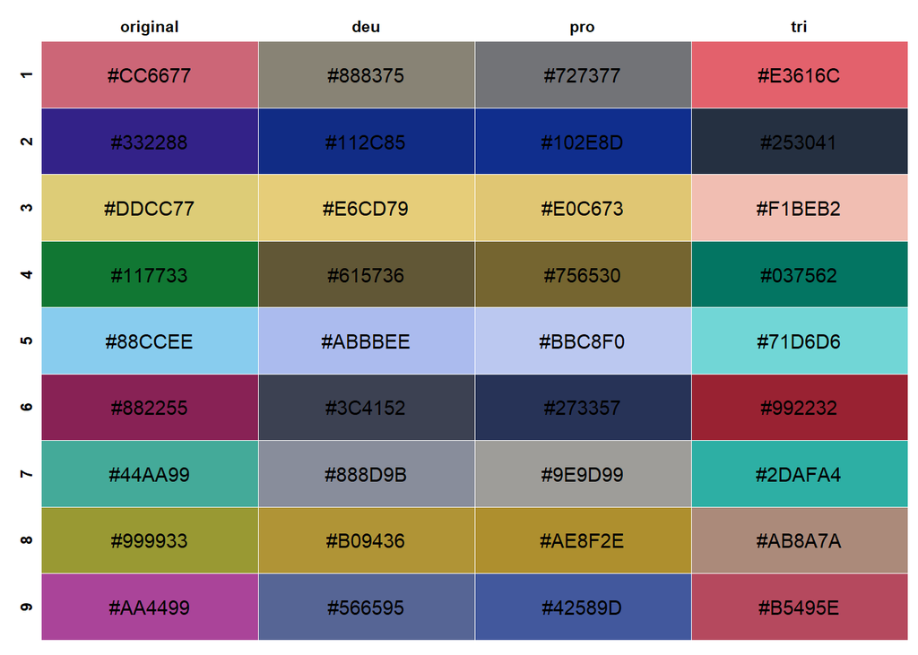

```r
khroma::colour("muted")(9) %>% as.vector %>% colRcvd %>% colRtidy %>% colRplot
```

Bright, vibrant and muted have quite a few grey tones that could be difficult to discern. Contrast looks like it would work well for a qualitative palette.

### 3.4 Finding a colour blind friendly diverging colour palette

Let’s look at Paul Tol’s colour palettes again to see which are distinct at both ends of the spectrum.

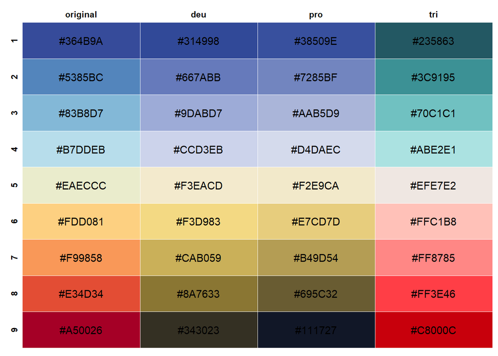

```r
khroma::colour("sunset")(9) %>% as.vector %>% colRcvd %>% colRtidy %>% colRplot
```

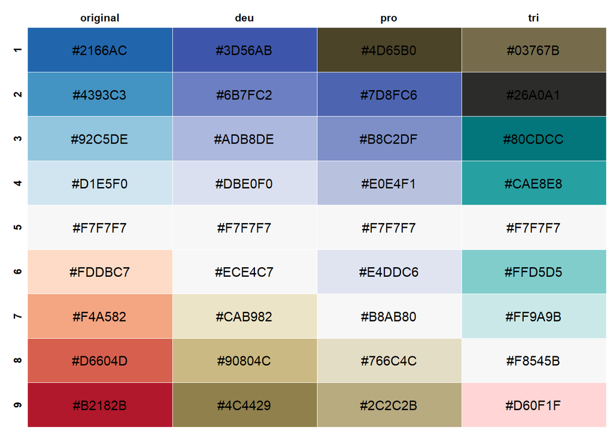

```r
khroma::colour("BuRd")(9) %>% as.vector %>% colRcvd %>% colRtidy %>% colRplot
```

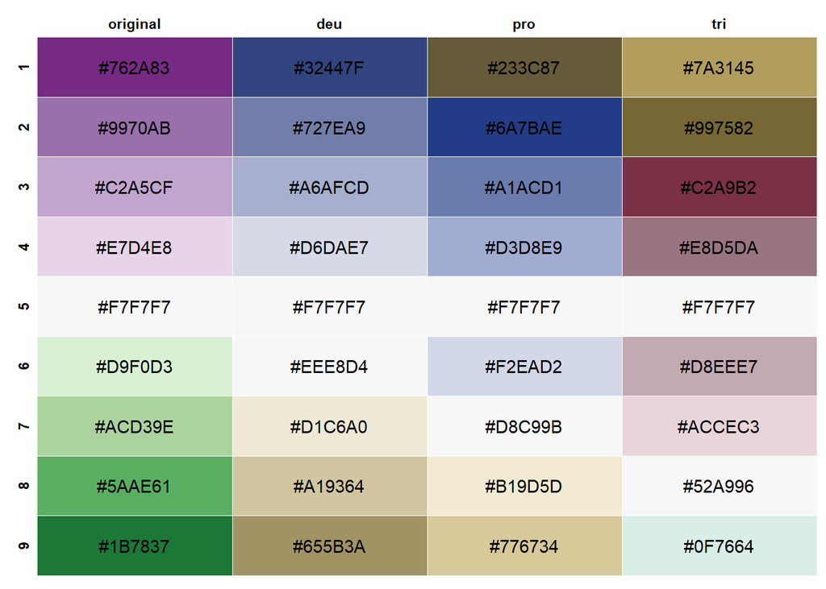

```r
khroma::colour("PRGn")(9) %>% as.vector %>% colRcvd %>% colRtidy %>% colRplot
```

### 3.5 Finding a colour blind friendly continuous colour palette

Let’s check out the rainbow colour palette. Are the colour changes uniform?

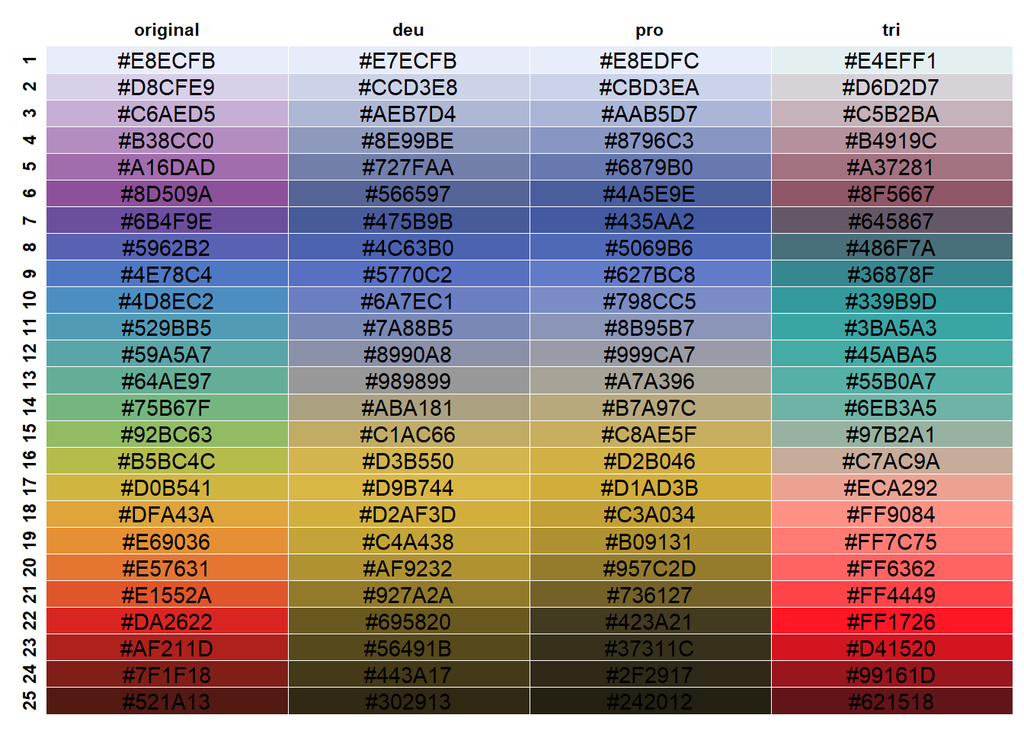

```r
khroma::colour("smooth rainbow")(25) %>% as.vector %>% colRcvd %>% colRtidy %>% colRplot
```

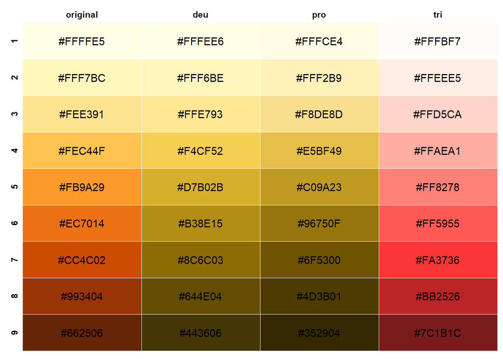

```r
khroma::colour("YlOrBr")(9) %>% as.vector %>% colRcvd %>% colRtidy %>% colRplot
```